# Tarea 1 - Semestre Otoño 2021

##### 4. EDA Cuadrimensional

Similar a la parte anterior, se evlíua cómo afectan tres variables a Rating. Esto para ver efectos aún más complejos entre variables explicativas que afecten al Rating:

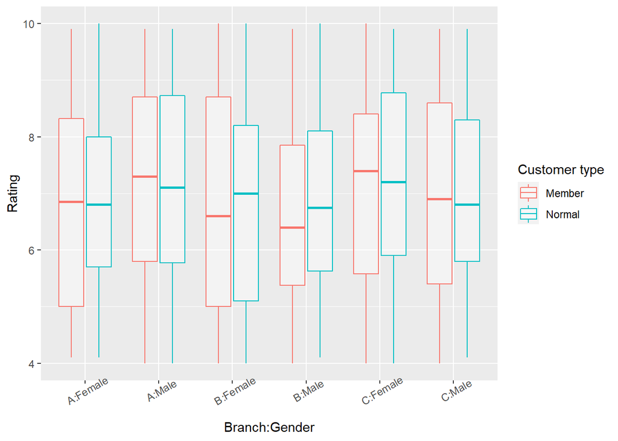

```r
#
# Cuadrimensional
#

#---------------------------------------------------------------------
# Branch:Gender v/s Rating

#35. Boxplot Branch:Gender v/s Rating r/ `Customer type`
ggplot(df) +
  aes(x=Branch:Gender, y=Rating, col=`Customer type`) +
  geom_boxplot(alpha=0.4, fill='white') + #cambiamos el tipo de gráfico
  theme(axis.text.x = element_text(angle = 30))
```

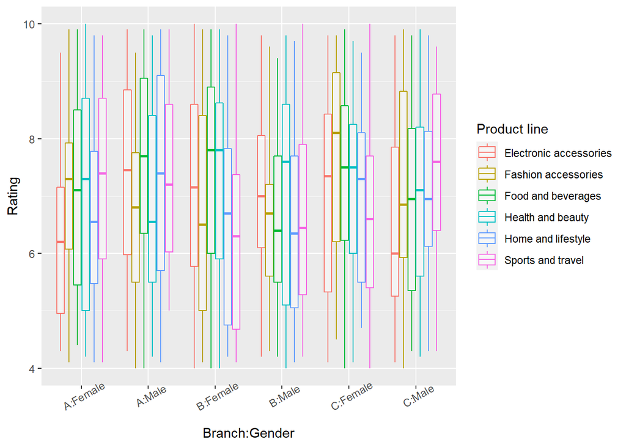

```r
#36. Boxplot Branch v/s Rating r/ `Product Line`
ggplot(df) +
  aes(x=Branch:Gender, y=Rating, col=`Product line`) +
  geom_boxplot(alpha=0.4, fill='white') + #cambiamos el tipo de gráfico
  theme(axis.text.x = element_text(angle = 30))
```

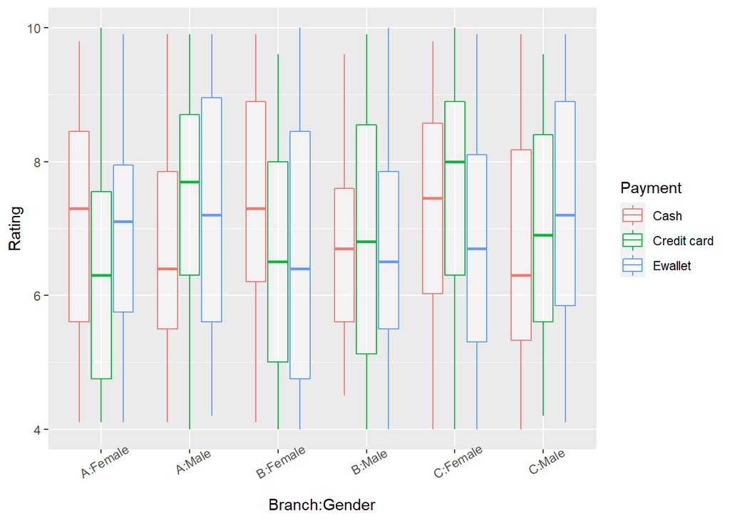

```r
#37. Boxplot Branch v/s Rating r/ Payment
ggplot(df) +
  aes(x=Branch:Gender, y=Rating, col=Payment) +
  geom_boxplot(alpha=0.4, fill='white') + #cambiamos el tipo de gráfico
  theme(axis.text.x = element_text(angle = 30))
```

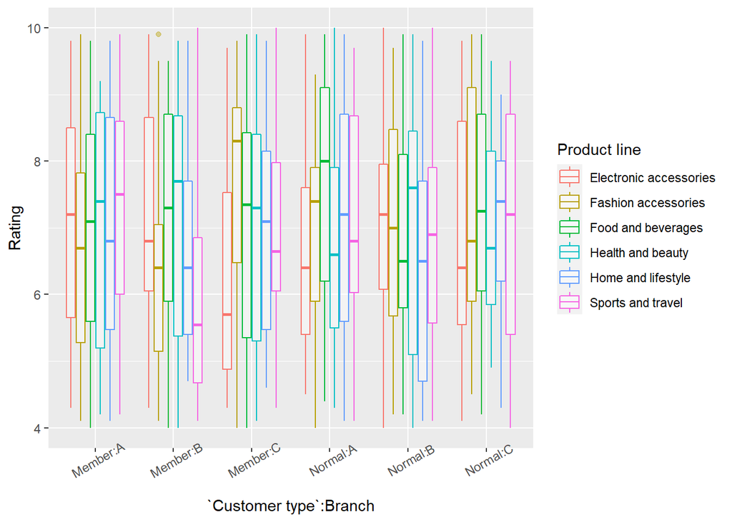

```r
# Branch:`Customer type` v/s Rating

#38. Boxplot Branch:`Customer type` v/s Rating r/ `Product Line`
ggplot(df) +
  aes(x=`Customer type`:Branch, y=Rating, col=`Product line`) +
  geom_boxplot(alpha=0.4, fill='white') + #cambiamos el tipo de gráfico
  theme(axis.text.x = element_text(angle = 30))
```

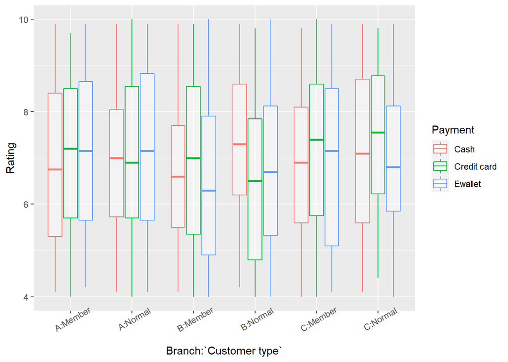

```r
#39. Boxplot Branch:`Customer type` v/s Rating r/ Payment
ggplot(df) +
  aes(x=Branch:`Customer type`, y=Rating, col=Payment) +
  geom_boxplot(alpha=0.4, fill='white') + #cambiamos el tipo de gráfico
  theme(axis.text.x = element_text(angle = 30))
```

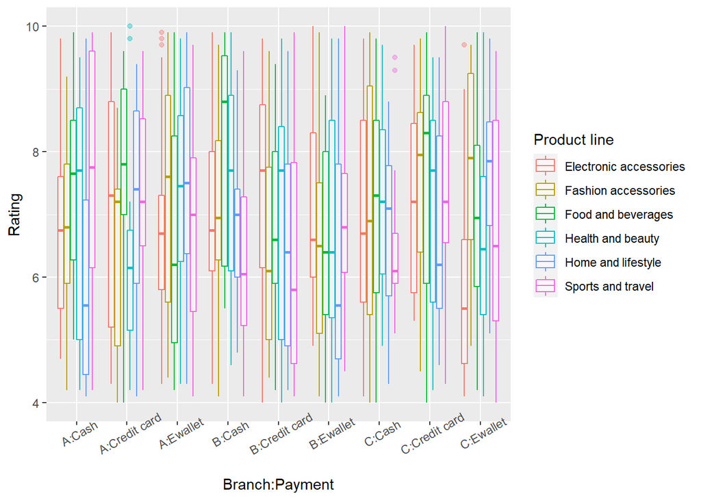

```r
# Branch:Payment v/s Rating

#40. Boxplot Branch:Payment v/s Rating r/ `Product Line`
ggplot(df) +
  aes(x=Branch:Payment, y=Rating, col=`Product line`) +
  geom_boxplot(alpha=0.4, fill='white') + #cambiamos el tipo de gráfico
  theme(axis.text.x = element_text(angle = 30))
```

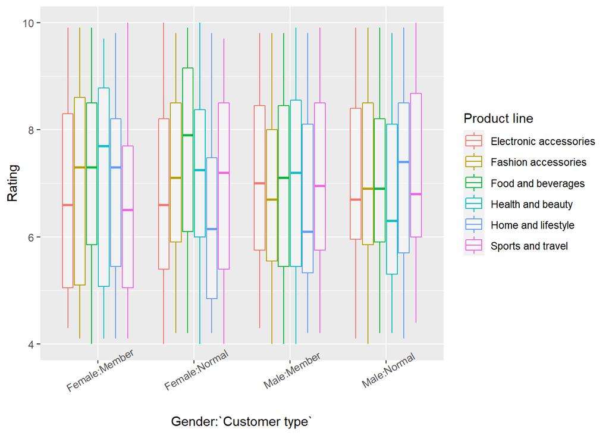

```r
#---------------------------------------------------------------------
# Gender:`Customer type` v/s Rating

#41. Boxplot Gender:`Customer type` v/s Rating r/ `Product line`
ggplot(df) +
  aes(x=Gender:`Customer type`, y=Rating, col=`Product line`) +
  geom_boxplot(alpha=0.4, fill='white') + #cambiamos el tipo de gráfico
  theme(axis.text.x = element_text(angle = 30))
```

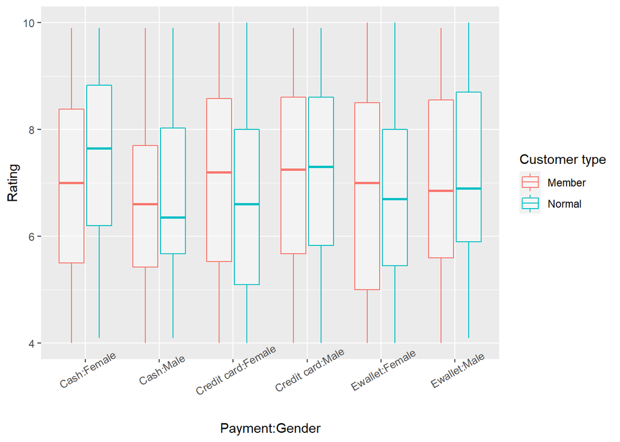

```r
#42. Boxplot Gender:`Customer type` v/s Rating r/ Payment
ggplot(df) +
  aes(x=Payment:Gender, y=Rating, col=`Customer type`) +
  geom_boxplot(alpha=0.4, fill='white') + #cambiamos el tipo de gráfico
  theme(axis.text.x = element_text(angle = 30))
```

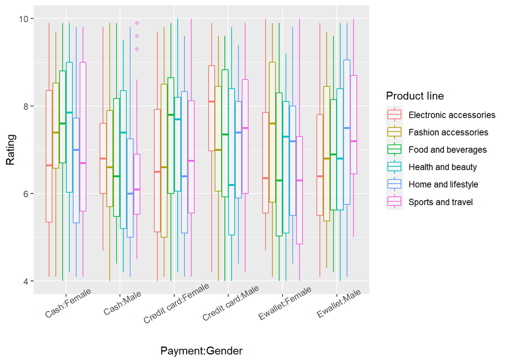

```r
# Gender:Payment v/s Rating

#43. Boxplot Gender:Payment v/s Rating r/ `Product line`
ggplot(df) +
  aes(x=Payment:Gender, y=Rating, col=`Product line`) +
  geom_boxplot(alpha=0.4, fill='white') + #cambiamos el tipo de gráfico
  theme(axis.text.x = element_text(angle = 30))
```

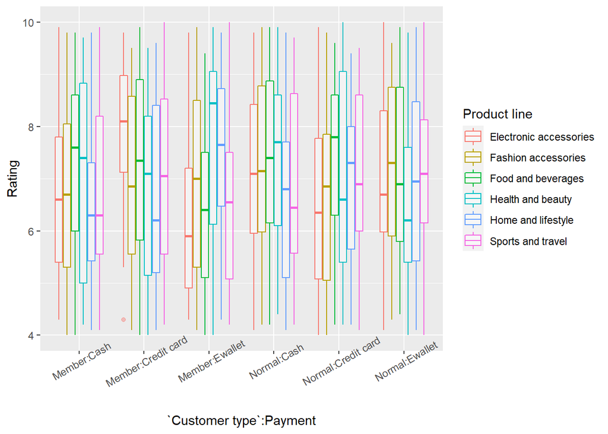

```r
#---------------------------------------------------------------------

# `Customer type`:Payment v/s Rating

#44. Boxplot `Customer type`:Payment v/s Rating r/ `Product line`
ggplot(df) +
  aes(x=`Customer type`:Payment, y=Rating, col=`Product line`) +
  geom_boxplot(alpha=0.4, fill='white') + #cambiamos el tipo de gráfico
  theme(axis.text.x = element_text(angle = 30))
```

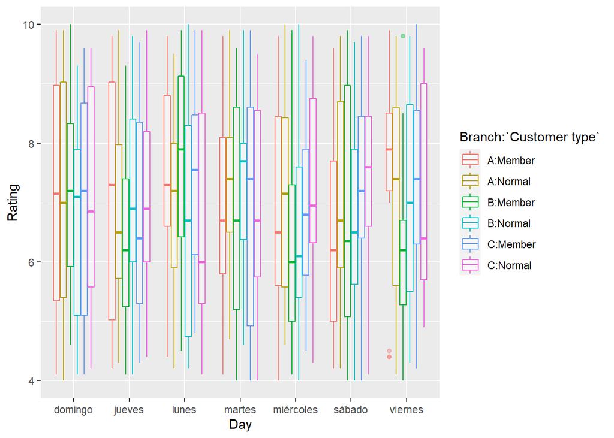

```r
#---------------------------------------------------------------------

# Tiempo incluído

#---------------------------------------------------------------------

# Tiempo agregado

#45. Boxplot Branch:`Customer type` v/s Rating r/ Day
ggplot(df) +
  aes(x=Day, y=Rating, col=Branch:`Customer type`) +
  geom_boxplot(alpha=0.4, fill='white') #cambiamos el tipo de gráfico
```

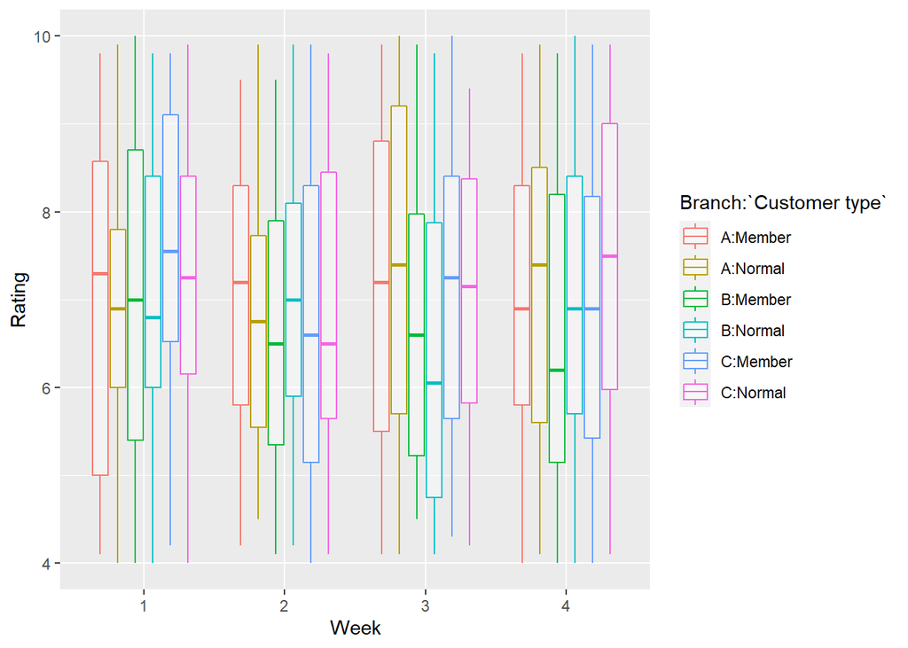

```r
#46. Boxplot Branch v/s Rating r/ Week
ggplot(df) +
  aes(x=Week, y=Rating, col=Branch:`Customer type`) +
  geom_boxplot(alpha=0.4, fill='white') #cambiamos el tipo de gráfico
```

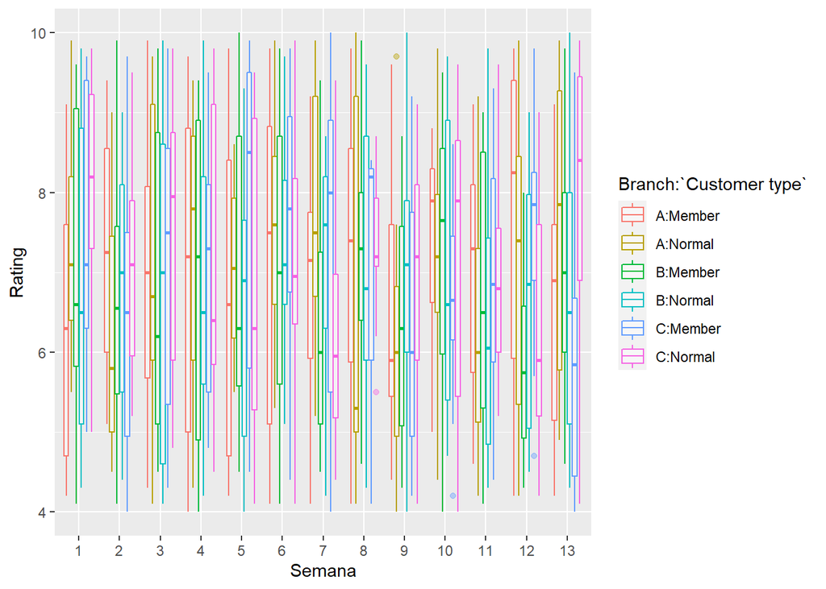

```r
# Tiempo contínuo

#47. Boxplot Branch v/s Rating r/ Week
ggplot(df) +
  aes(x=Semana, y=Rating, col=Branch:`Customer type`) +
  geom_boxplot(alpha=0.4, fill='white') #cambiamos el tipo de gráfico
```

```r
#48. Boxplot Branch v/s Rating r/ Week
ggplot(df) +
  aes(x=Month, y=Rating, col=Branch:`Customer type`) +
  geom_boxplot(alpha=0.4, fill='white') #cambiamos el tipo de gráfico
```

[output not shown]

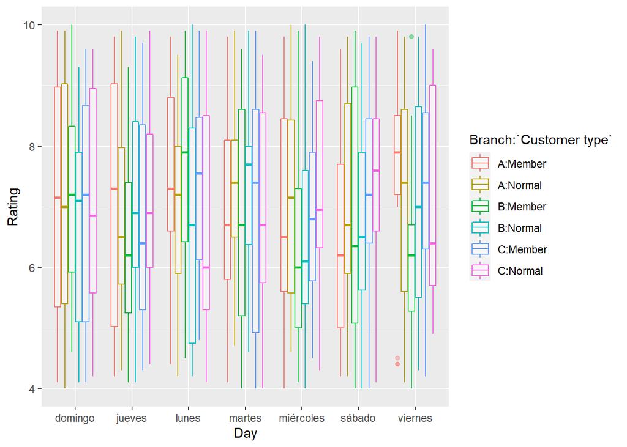

```r
#---------------------------------------------------------------------

# Tiempo agregado

#49. Boxplot Branch:`Customer type` v/s Rating r/ Day
ggplot(df) +
  aes(x=Day, y=Rating, col=Branch:`Customer type`) +
  geom_boxplot(alpha=0.4, fill='white') #cambiamos el tipo de gráfico
```

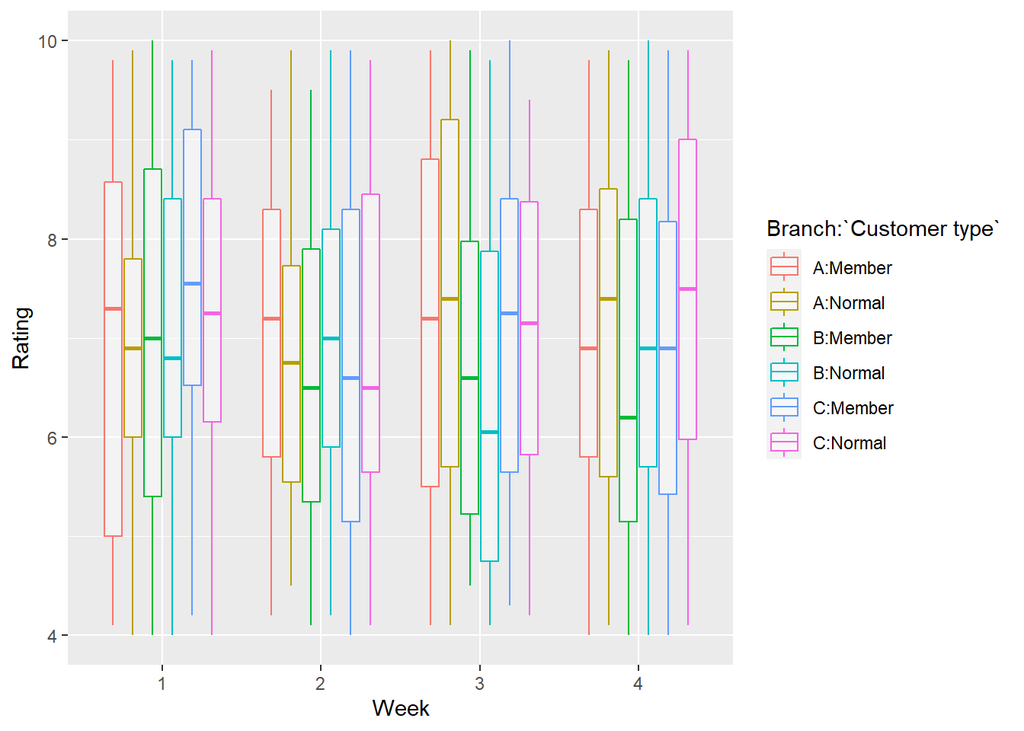

```r
#50. Boxplot Branch v/s Rating r/ Week
ggplot(df) +
  aes(x=Week, y=Rating, col=Branch:`Customer type`) +
  geom_boxplot(alpha=0.4, fill='white') #cambiamos el tipo de gráfico
```

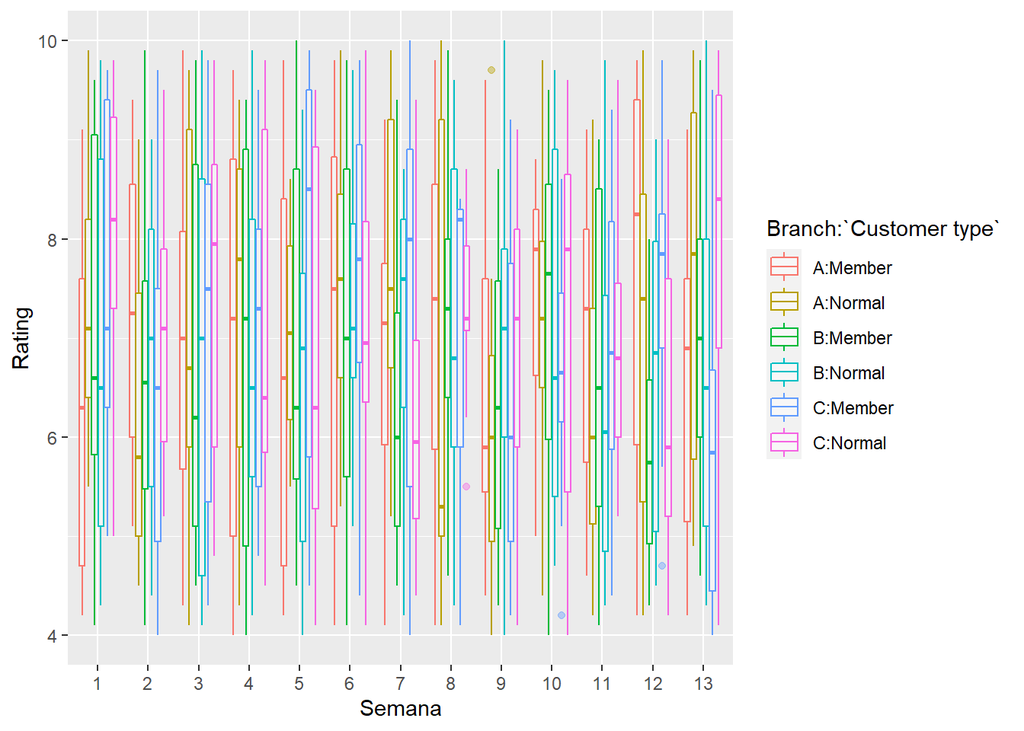

```r
# Tiempo contínuo

#51. Boxplot Branch v/s Rating r/ Week
ggplot(df) +
  aes(x=Semana, y=Rating, col=Branch:`Customer type`) +
  geom_boxplot(alpha=0.4, fill='white') #cambiamos el tipo de gráfico
```

```r
#52. Boxplot Branch v/s Rating r/ Week
ggplot(df) +
  aes(x=Month, y=Rating, col=Branch:`Customer type`) +
  geom_boxplot(alpha=0.4, fill='white') #cambiamos el tipo de gráfico
```

[output not shown]

Se pueden ver efectos aún más notorios partiendo de los resultados interesantes anteriores. La combinación de variables Género/Pago/línea de producto parece tener mucha variación en el Rating, por lo que se tendrá presente en el resto del desarrollo.

En cuanto a otras, se puede destacar Branch/Tipo de cliente/ Porduct line también tiene bastante variabilidad en Rating.

#### Pregunta 2

(2.0 puntos) Usando los aprendizajes derivados de la exploración de datos, use un enfoque de regresión lineal para examinar cuantitativamente qué factores determinan la satisfacción al momento de realizar una compra.

**a)** Proponga al menos dos especificaciones alternativas para el objetivo propuesto. Justifique muy brevemente por que las variables que está incluyendo en el modelo tienen sentido desde el punto de vista del negocio. Justifique además el nivel de agregación escogido y los índices considerados en el modelo.

1. En primera instancia se va a correr una regresión sólo con las variables que no guardan relación con el resto, tal cual vienen en la base. Esto es, no incluir dos varibles independientes tal que una se pueda explicar por la otra.

- Customer type: se esperaría que haya cambios según se es miembro o no (ej. si es miembro puede ser más exigente a la hora de evaluar la tienda)
- Gender: se esperaría un efecto según se es H/M (ej. cierto género es más exigente a la hora de evaluar)
- Product line: podría haber cambios en el rating por la línea de producto
- Unit price: se esperaría que mientras más caro un producto, menor rating
- Quantity: a mayor cantidad, menor rating
- Unit price*Quantity: (Contiene información de Cogs), se esperaría que a mayor valor, menor rating
- Month: dependiendo del mez, podría cambiar el rating (por ejemplo si es marzo)
- Day: ciertos días podría variar el rating (ej. un lunes donde es comienzo de semana, podría bajar la nota dados los estados de ánimo)
- Hour: ciertas horas del día, podrían variar el rating.

En cuanto al nivel de agregación, interesa ver cómo se ve afectado el Rating según fechas (mes, día, …)

```r
#Regresion lineal sin diferenciar por tienda

train.lm <- train(form = Rating ~ Branch + `Customer type` + Gender + `Product line` + `Unit price` +  Quantity + `Unit price`*Quantity + Payment + Month + Day + Hour, #Fórmula
                  data = train, #Datos
                  method = "lm", #Algoritmo
                  trControl = trainControl(method = "cv", number = 5) #Method = cross validation, number=10 (k-fold)
)
test.lm  <- predict(train.lm , newdata=test) #Vector de datos predichos. Recibe una base de datos (newdata) y un modelo entrenado (train.lm)
error.lm <- test$Rating-test.lm #Calcular los errores de predicción (dato real - dato estimado)
summary(train.lm)
```

```
##
## Call:
## lm(formula = .outcome ~ ., data = dat)
##
## Residuals:
##     Min      1Q  Median      3Q     Max
## -3.5378 -1.3775 -0.0606  1.4100  3.8126
##
## Coefficients:
##                                           Estimate Std. Error t value Pr(>|t|)
## (Intercept)                              6.3326138  0.4545214  13.932   <2e-16
## BranchB                                 -0.1875735  0.1493689  -1.256   0.2096
## BranchC                                  0.1002278  0.1497354   0.669   0.5035
## `\\`Customer type\\`Normal`              0.0608326  0.1237893   0.491   0.6233
## GenderMale                               0.1620288  0.1236948   1.310   0.1906
## `\\`Product line\\`Fashion accessories`  0.1023654  0.2082803   0.491   0.6232
## `\\`Product line\\`Food and beverages`   0.1533843  0.2098984   0.731   0.4652
## `\\`Product line\\`Health and beauty`   -0.1511648  0.2174071  -0.695   0.4871
## `\\`Product line\\`Home and lifestyle`  -0.1655549  0.2122794  -0.780   0.4357
## `\\`Product line\\`Sports and travel`   -0.0126940  0.2144517  -0.059   0.9528
## `\\`Unit price\\``                       0.0091765  0.0049694   1.847   0.0652
## Quantity                                 0.0866420  0.0488633   1.773   0.0766
## `PaymentCredit card`                    -0.0046919  0.1506331  -0.031   0.9752
## PaymentEwallet                           0.0794157  0.1488282   0.534   0.5938
## Month2                                   0.2697336  0.1534868   1.757   0.0793
## Month3                                  -0.1478791  0.1465638  -1.009   0.3133
## Dayjueves                               -0.2462967  0.2363351  -1.042   0.2977
## Daylunes                                 0.0874104  0.2439506   0.358   0.7202
## Daymartes                                0.0853699  0.2291358   0.373   0.7096
## Daymiércoles                            -0.2737481  0.2331233  -1.174   0.2407
## Daysábado                               -0.0913286  0.2265855  -0.403   0.6870
## Dayviernes                               0.0316197  0.2354423   0.134   0.8932
## Hour11                                   0.0092623  0.2750106   0.034   0.9731
## Hour12                                   0.2909585  0.2735303   1.064   0.2878
## Hour13                                   0.2436276  0.2715694   0.897   0.3699
## Hour14                                  -0.0318068  0.2883404  -0.110   0.9122
## Hour15                                  -0.1541163  0.2695338  -0.572   0.5676
## Hour16                                  -0.1196080  0.2927224  -0.409   0.6829
## Hour17                                  -0.0067216  0.2924917  -0.023   0.9817
## Hour18                                   0.2431299  0.2696125   0.902   0.3675
```

[output cut: 28 more lines]

```
## Hour13
## Hour14
## Hour15
## Hour16
## Hour17
## Hour18
## Hour19
## Hour20
## `\\`Unit price\\`:Quantity`             .
## ---
## Signif. codes:  0 '***' 0.001 '**' 0.01 '*' 0.05 '.' 0.1 ' ' 1
##
## Residual standard error: 1.709 on 767 degrees of freedom
## Multiple R-squared:  0.04544,    Adjusted R-squared:  0.005616
## F-statistic: 1.141 on 32 and 767 DF,  p-value: 0.2726
```

```r
print(paste('Error de predicción: ', mean(abs(error.lm))))
```

```
## [1] "Error de predicción:  1.57274541734021"
```

Se puede ver que la variable de interés no se explica muy bien por las variables independientes de este modelo, lo cual tiene sentido según el EDA bidimensional realizado en la parte anterior.

2. Agregamos a la regresión la variable Week, donde podría haber un efecto al pasar el tiempo en semanas.

```r
#2. Regresion lineal con intervalos temporales
train.lm2 <- train(form = Rating ~ Branch + `Customer type` + Gender + `Product line` + `Unit price` + Quantity + `Unit price`*Quantity + Payment + Month + Week + Day + Hour, #Fórmula
                  data = train, #Datos
                  method = "lm", #Algoritmo
                  na.action = na.pass, # Ignorar NA
                  trControl = trainControl(method = "cv", number = 5) #Method = cross validation, number=10 (k-fold)
)
test.lm2  <- predict(train.lm2 , newdata=test) #Vector de datos predichos. Recibe una base de datos (newdata) y un modelo entrenado (train.lm)
error.lm2 <- test$Rating-test.lm2 #Calcular los errores de predicción (dato real - dato estimado)
summary(train.lm2)
```

```
##
## Call:
## lm(formula = .outcome ~ ., data = dat)
##
## Residuals:
##     Min      1Q  Median      3Q     Max
## -3.5016 -1.3530 -0.0752  1.3959  3.7915
##
## Coefficients: (1 not defined because of singularities)
##                                           Estimate Std. Error t value Pr(>|t|)
## (Intercept)                              6.5180019  0.4685856  13.910   <2e-16
## BranchB                                 -0.1882269  0.1492830  -1.261   0.2077
## BranchC                                  0.1111279  0.1499410   0.741   0.4588
## `\\`Customer type\\`Normal`              0.0663451  0.1237283   0.536   0.5920
## GenderMale                               0.1779596  0.1239608   1.436   0.1515
## `\\`Product line\\`Fashion accessories`  0.1053236  0.2082167   0.506   0.6131
## `\\`Product line\\`Food and beverages`   0.1607865  0.2100249   0.766   0.4442
## `\\`Product line\\`Health and beauty`   -0.1677699  0.2177098  -0.771   0.4412
## `\\`Product line\\`Home and lifestyle`  -0.1671204  0.2125886  -0.786   0.4320
## `\\`Product line\\`Sports and travel`   -0.0161915  0.2148423  -0.075   0.9399
## `\\`Unit price\\``                       0.0090819  0.0049977   1.817   0.0696
## Quantity                                 0.0837009  0.0489604   1.710   0.0878
## `PaymentCredit card`                    -0.0007725  0.1506281  -0.005   0.9959
## PaymentEwallet                           0.0771112  0.1488178   0.518   0.6045
## Month2                                   0.2527174  0.1548127   1.632   0.1030
## Month3                                  -0.1513383  0.1473349  -1.027   0.3047
## Week2                                   -0.3314942  0.1743238  -1.902   0.0576
## Week3                                   -0.2716683  0.1791097  -1.517   0.1297
## Week4                                   -0.1676707  0.1687513  -0.994   0.3207
## Week5                                           NA         NA      NA       NA
## Dayjueves                               -0.2526009  0.2363322  -1.069   0.2855
## Daylunes                                 0.0887403  0.2438780   0.364   0.7161
## Daymartes                                0.0832006  0.2289853   0.363   0.7164
## Daymiércoles                            -0.2739643  0.2333193  -1.174   0.2407
## Daysábado                               -0.0891751  0.2264591  -0.394   0.6939
## Dayviernes                               0.0480636  0.2361156   0.204   0.8388
## Hour11                                  -0.0039577  0.2750120  -0.014   0.9885
## Hour12                                   0.3075444  0.2741666   1.122   0.2623
## Hour13                                   0.2321931  0.2716073   0.855   0.3929
## Hour14                                  -0.0204863  0.2882352  -0.071   0.9434
```

[output cut: 36 more lines]

```
## Hour13
## Hour14
## Hour15
## Hour16
## Hour17
## Hour18
## Hour19
## Hour20
## `\\`Unit price\\`:Quantity`             .
## ---
## Signif. codes:  0 '***' 0.001 '**' 0.01 '*' 0.05 '.' 0.1 ' ' 1
##
## Residual standard error: 1.707 on 764 degrees of freedom
## Multiple R-squared:  0.05061,    Adjusted R-squared:  0.007117
## F-statistic: 1.164 on 35 and 764 DF,  p-value: 0.2396
```

```r
print(paste('Error de predicción: ', mean(abs(error.lm2))))
```

```
## [1] "Error de predicción:  1.57153674416614"
```

Se puede observar que este modelo tampoco explica de la forma deseada la variable de interés (poca significancia), sin embargo, disminuye el error de predicción.

3. Regresión con interacciones “Branch x Customer type x Month” y “Gender x Payment x Product line”, pues se vio en el EDA cuadrimensional ciertas variaciones notables en la variable de interés.

```r
#3.Regresion lineal con intervalos temporales
train.lm3 <- train(form = Rating ~
                    Branch * `Customer type` * Month  +
                    Gender  * Payment * `Product line` +
                    `Unit price`+ Quantity +
                    Hour + Day + Week, #Fórmula
                  data = train, #Datos
                  method = "lm", #Algoritmo
                  na.action = na.pass, # Ignorar NA
                  trControl = trainControl(method = "cv", number = 5) #Method = cross validation, number=10 (k-fold)
)
test.lm3  <- predict(train.lm3 , newdata=test) #Vector de datos predichos. Recibe una base de datos (newdata) y un modelo entrenado (train.lm)
error.lm3 <- test$Rating-test.lm3 #Calcular los errores de predicción (dato real - dato estimado)
summary(train.lm3)
```

```
##
## Call:
## lm(formula = .outcome ~ ., data = dat)
##
## Residuals:
##     Min      1Q  Median      3Q     Max
## -3.6713 -1.3371 -0.0389  1.2823  3.9926
##
## Coefficients: (1 not defined because of singularities)
##                                                                        Estimate
## (Intercept)                                                            7.121951
## BranchB                                                               -0.021716
## BranchC                                                                0.113667
## `\\`Customer type\\`Normal`                                            0.233471
## Month2                                                                 0.105347
## Month3                                                                -0.001520
## GenderMale                                                            -0.099767
## `PaymentCredit card`                                                  -0.960483
## PaymentEwallet                                                        -0.249986
## `\\`Product line\\`Fashion accessories`                               -0.152017
## `\\`Product line\\`Food and beverages`                                 0.418573
## `\\`Product line\\`Health and beauty`                                  0.126821
## `\\`Product line\\`Home and lifestyle`                                -0.396972
## `\\`Product line\\`Sports and travel`                                 -0.102165
## `\\`Unit price\\``                                                     0.001614
## Quantity                                                               0.006418
## Hour11                                                                -0.019423
## Hour12                                                                 0.255257
## Hour13                                                                 0.192387
## Hour14                                                                 0.003309
## Hour15                                                                -0.133373
## Hour16                                                                -0.060921
## Hour17                                                                 0.039651
## Hour18                                                                 0.235185
## Hour19                                                                -0.516029
## Hour20                                                                 0.178006
## Dayjueves                                                             -0.167193
## Daylunes                                                               0.130123
## Daymartes                                                              0.132925
## Daymiércoles                                                          -0.209126
```

[output cut: 340 more lines]

```
## `GenderMale:PaymentEwallet:\\`Product line\\`Fashion accessories`
## `GenderMale:PaymentCredit card:\\`Product line\\`Food and beverages`
## `GenderMale:PaymentEwallet:\\`Product line\\`Food and beverages`
## `GenderMale:PaymentCredit card:\\`Product line\\`Health and beauty`
## `GenderMale:PaymentEwallet:\\`Product line\\`Health and beauty`
## `GenderMale:PaymentCredit card:\\`Product line\\`Home and lifestyle`
## `GenderMale:PaymentEwallet:\\`Product line\\`Home and lifestyle`
## `GenderMale:PaymentCredit card:\\`Product line\\`Sports and travel`
## `GenderMale:PaymentEwallet:\\`Product line\\`Sports and travel`
## ---
## Signif. codes:  0 '***' 0.001 '**' 0.01 '*' 0.05 '.' 0.1 ' ' 1
##
## Residual standard error: 1.708 on 726 degrees of freedom
## Multiple R-squared:  0.09654,    Adjusted R-squared:  0.005692
## F-statistic: 1.063 on 73 and 726 DF,  p-value: 0.3446
```

```r
print(paste('Error de predicción: ', mean(abs(error.lm3))))
```

```
## [1] "Error de predicción:  1.54585929801487"
```

Disminuye el error de predicción, sin embargo, hay poca siginificancia en las variables.

4. Separamos ahora la regresión por tiendas/branches, pues puede explicarse el rating según la tienda, teniendo efectos independientes. Además, se agrega las interacciones anteriores.

```r
#4. Regresion lineal diferenciando por tienda
allstores = unique(train$Branch) # Valores únicos de cada tienda

nobs = nrow(train)  # filas del set de training
nbranches = length(allstores) # n de tiendas

atributos_interes <- c('Total','Gender')
#regcoeff = array(NA, dim=c(nbranches,length(atributos_interes))) # matriz auxiliar vacía para los coefs de las 3 tiendas
regcoeff = array(NA, dim=c(nbranches,11))
# Loop en las tiendas
for (i in 1:nbranches){

  sub_train <- train[(train$Branch==allstores[i]),]



  #regrmodel = lm(Rating2 ~ Uprice + Gender2 + Semana2)
  reg_model <- lm(Rating ~
                     `Customer type` * Month  +
                    Gender  * Payment * `Product line` +
                    `Unit price`+ Quantity +
                    Hour + Day + Week, #Fórmula,
                  data = sub_train)

  #print(summary(reg_model))
 # print(reg_model$coeff)
  #regcoeff[i,] = reg_model$coeff

  sub_test <- test[test$Branch==allstores[i],]
  test.lm4  <- predict(reg_model , newdata=sub_test) #Vector de datos predichos. Recibe una base de datos (newdata) y un modelo entrenado (train.lm)
  error.lm4 <- (sub_test$Rating -  test.lm4) #Calcular los errores de predicción (dato real - dato estimado)
  summary(reg_model)
  print(paste('Branch:', allstores[i],'\tError:',mean(abs(error.lm4))))
}
```

```
## [1] "Branch: C \tError: 1.63430085132589"
## [1] "Branch: B \tError: 1.56572528375562"
## [1] "Branch: A \tError: 1.5596743606898"
```

Se puede observar distitnos errores de predicción según tienda.

**b)** Sobre los dos modelos planteados en la parte anterior, aplique un método de selección automática de variables y compare respecto a los resultados anteriores.

Para esta parte, se continuará trabajando con el modelo que mejor funcionó en las partes anteriores (menor error de predicción):

Rating = Branch * Customer type * Month + Gender * Payment * Product line + Hour + Day + Week + Unit price * Quantity

1. Se usa LASSO para seleccionar las varibles más importantes de la regresión anterior, ya que va a castigar a los coeficientes que tengan mayor error llevando algunos a 0.

```r
#Regresión autoselección
# Lasso

train.lasso <- train(form = Rating ~
                      Branch * `Customer type` * Month  +
                      Gender  * Payment * `Product line` +
                      Hour + Day + Week +
                     `Unit price`*Quantity, #Fórmula
                  data = train, #Datos
                  method = "glmnet", #Algoritmo
                  tuneGrid = expand.grid(alpha = 1, lambda = 1),
                  trControl = trainControl(method = "cv", number = 5) #Method = cross validation, number=10 (k-fold)
)
test.lasso  <- predict(train.lasso , newdata=test) #Vector de datos predichos. Recibe una base de datos (newdata) y un modelo entrenado (train.lm)
error.lasso <- test$Rating-test.lasso #Calcular los errores de predicción (dato real - dato estimado)

print(paste('Error de predicción: ', mae(train$Rating,test.lasso)))
```

```
## [1] "Error de predicción:  1.468375"
```

Se observa una baja en el error de predicción, por lo que funciona la selección de variables.

2. Se usa Regression Ridge para tener una segunda métrica de selección; sin embargo, esta en realidad no selecciona variables, si no que le baja la magnitud a variables que aporten menos a la disminución de error

```r
# Regresión NO-autoselección
# Ridge

train.rr <- train(form = Rating ~
                      Branch * `Customer type` * Month  +
                      Gender  * Payment * `Product line` +
                      Hour + Day + Week +
                      `Unit price`*Quantity, #Fórmula
                  data = train, #Datos
                  method = "glmnet", #Algoritmo
                  tuneGrid = expand.grid(alpha = 0, lambda = 1),
                  trControl = trainControl(method = "cv", number = 5) #Method = cross validation, number=10 (k-fold)
)
test.rr <- predict(train.rr , newdata=test) #Vector de datos predichos. Recibe una base de datos (newdata) y un modelo entrenado (train.lm)
error.rr <- test$Rating-test.rr #Calcular los errores de predicción (dato real - dato estimado)

print(paste('Error de predicción: ', mae(train$Rating,test.rr)))
```

```
## [1] "Error de predicción:  1.46478292927359"
```

Como sólo se eleccionaron variables con LASSO, se necesita un segundo método de selección de variables para completar el análisis pedido. Usamos entonces la Stepwise Regression (Backward):

```r
#Regresión autoselección
# stepwise backward

train.swb <- train(form = Rating ~
                      Branch * `Customer type` * Month  +
                      Gender  * Payment * `Product line` +
                      Hour + Day + Week +
                      `Unit price`*Quantity, #Fórmula
                  data = train, #Datos
                  method = "leapBackward", #Algoritmo
                  tuneGrid = data.frame(nvmax = 1:15),
                  trControl = trainControl(method = "cv", number = 5)#Method = cross validation, number=10 (k-fold)
)
```

```
## Reordering variables and trying again:
## Reordering variables and trying again:
## Reordering variables and trying again:
## Reordering variables and trying again:
## Reordering variables and trying again:
## Reordering variables and trying again:
```

```r
test.swb <- predict(train.swb , newdata=test) #Vector de datos predichos. Recibe una base de datos (newdata) y un modelo entrenado (train.lm)
error.swb <- test$Rating-test.swb #Calcular los errores de predicción (dato real - dato estimado)

print(paste('Error de predicción: ', mae(train$Rating,test.swb)))
```

```
## [1] "Error de predicción:  1.46265344599156"
```

### Comparación de resultados

A continuación, se comparan los modelos anteriores (regresiones lineales y selección automática)

```r
rating.test <- data.frame(lm1=test.lm, lm2=test.lm2, lm3=test.lm3, lasso=test.lasso, ridge=test.rr, step.back=test.swb, rating=test$Rating)
error.test <- data.frame(lm1=error.lm, lm2=error.lm2, lm3=error.lm3, lasso=error.lasso, ridge=error.rr, step.back=error.swb)

summary(abs(error.test))
```

```
##       lm1               lm2              lm3             lasso
##  Min.   :0.00038   Min.   :0.0157   Min.   :0.0217   Min.   :0.03188
##  1st Qu.:0.74269   1st Qu.:0.7677   1st Qu.:0.6345   1st Qu.:0.76812
##  Median :1.66285   Median :1.6428   Median :1.4935   Median :1.46812
##  Mean   :1.57275   Mean   :1.5715   Mean   :1.5459   Mean   :1.51432
##  3rd Qu.:2.35663   3rd Qu.:2.3365   3rd Qu.:2.3692   3rd Qu.:2.24094
##  Max.   :3.46866   Max.   :3.5973   Max.   :3.8573   Max.   :3.03187
##      ridge           step.back
##  Min.   :0.01143   Min.   :0.01491
##  1st Qu.:0.67252   1st Qu.:0.73191
##  Median :1.59631   Median :1.56768
##  Mean   :1.54315   Mean   :1.53873
##  3rd Qu.:2.31284   3rd Qu.:2.32232
##  Max.   :3.46251   Max.   :3.13491
```

```r
summary(error.test)
```

```
##       lm1                lm2                lm3               lasso
##  Min.   :-3.40411   Min.   :-3.59729   Min.   :-3.85726   Min.   :-2.96813
##  1st Qu.:-1.59278   1st Qu.:-1.55349   1st Qu.:-1.50520   1st Qu.:-1.46812
##  Median : 0.01848   Median : 0.05954   Median :-0.08578   Median : 0.03188
##  Mean   : 0.03088   Mean   : 0.03550   Mean   :-0.03719   Mean   : 0.02287
##  3rd Qu.: 1.72824   3rd Qu.: 1.69872   3rd Qu.: 1.47864   3rd Qu.: 1.53188
##  Max.   : 3.46866   Max.   : 3.39929   Max.   : 3.67198   Max.   : 3.03187
##      ridge             step.back
##  Min.   :-3.448731   Min.   :-3.13491
##  1st Qu.:-1.496715   1st Qu.:-1.49198
##  Median :-0.057609   Median : 0.01862
##  Mean   :-0.004616   Mean   : 0.01477
##  3rd Qu.: 1.631294   3rd Qu.: 1.64547
##  Max.   : 3.462505   Max.   : 3.11491
```

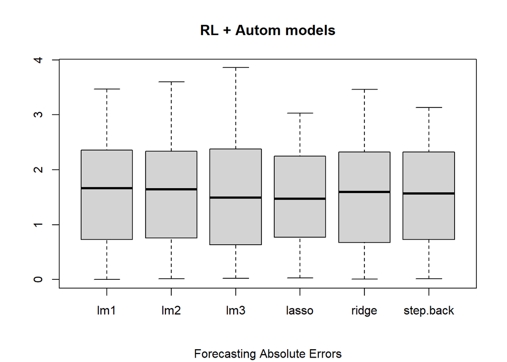

```r
boxplot(abs(subset(error.test))); title(main="RL + Autom models", sub="Forecasting Absolute Errors")
```

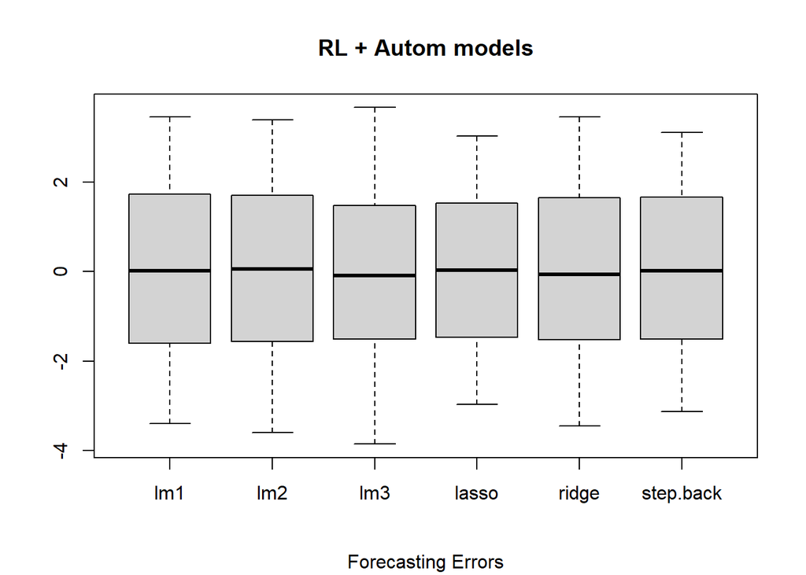

```r
boxplot(subset(error.test)); title(main="RL + Autom models", sub="Forecasting Errors")
```

#### Pregunta 3

(1.0 puntos) Use al menos dos de los modelos de aprendizaje de máquinas que vimos en clases (MARS, kNN, regression tree, random forest) para generar un pronóstico de Rating de un cliente al realizar una compra y compare la capacidad de estos modelos con respecto a los de regresión lineal.

Como KNN es un método que depende de una métrica de distancia (default euclidiana), entonces no se puede simplemente comparar los atributos numéricos con los categóricos, se necesita hacerlos comparables a ambos para que no dependa todo sólo de los numéricos. En este caso, se puede normalizar con el método de Min-Max:

```
##    Invoice.ID Branch      City Customer.type Gender           Product.line
## 1 740-11-5257      C Naypyitaw        Normal   Male Electronic accessories
## 2 582-52-8065      B  Mandalay        Normal Female    Fashion accessories
## 3 522-57-8364      A    Yangon        Member   Male    Fashion accessories
## 4 269-10-8440      A    Yangon        Member   Male      Health and beauty
## 5 277-35-5865      C Naypyitaw        Member Female     Food and beverages
## 6 343-75-9322      B  Mandalay        Member Female      Sports and travel
##   Unit.price  Quantity  Tax.5.    Total       Date     Time Payment   cogs
## 1 0.16226751 1.0000000 12.3700 259.7700 2019-02-24 16:44:00    Cash 247.40
## 2 0.49159149 0.8888889 24.4395 513.2295 2019-02-22 10:49:00    Cash 488.79
## 3 0.45851431 0.7777778 20.5360 431.2560 2019-01-31 10:00:00 Ewallet 410.72
## 4 0.47889520 0.6666667 18.6095 390.7995 2019-01-21 18:01:00    Cash 372.19
## 5 0.98897427 0.8888889 44.5365 935.2665 2019-03-09 11:23:00    Cash 890.73
## 6 0.01871032 0.7777778  4.7400  99.5400 2019-01-09 16:34:00    Cash  94.80
##   gross.margin.percentage gross.income Rating Hour Month       Day Frac_Day
## 1                4.761905      12.3700    7.1   16     2   domingo        3
## 2                4.761905      24.4395    8.9   10     2   viernes        1
## 3                4.761905      20.5360    7.6   10     1    jueves        1
## 4                4.761905      18.6095    8.9   18     1     lunes        4
## 5                4.761905      44.5365    6.7   11     3    sábado        1
## 6                4.761905       4.7400    4.1   16     1 miércoles        3
##   Week Semana
## 1    4      8
## 2    4      8
## 3    4      5
## 4    3      4
## 5    2     10
## 6    2      2
```

##### 1. KNN

```r
#Modelo de aprendizaje de máquinas
#1. ML --> KNN
train.knn.prediction<- train(Rating ~
                      Branch * Customer.type* Month  +
                      Gender  * Payment * Product.line +
                      Hour + Day + Week +
                      Unit.price*Quantity, #Fórmula
                   data=train.knn,
                   method="knn",
                   trControl = trainControl("cv", number=10),
                   preProcess = c("center","scale"),
                   tuneLength = 10
)

print(train.knn.prediction)
```

```
## k-Nearest Neighbors
##
## 800 samples
##  11 predictor
##
## Pre-processing: centered (75), scaled (75)
## Resampling: Cross-Validated (10 fold)
## Summary of sample sizes: 720, 720, 720, 719, 721, 720, ...
## Resampling results across tuning parameters:
##
##   k   RMSE      Rsquared     MAE
##    5  1.852908  0.015618570  1.551012
##    7  1.824203  0.013516871  1.533851
##    9  1.799062  0.009782702  1.520791
##   11  1.766886  0.011316643  1.490710
##   13  1.753405  0.010514961  1.480536
##   15  1.748168  0.010161166  1.481517
##   17  1.745071  0.011971273  1.480302
##   19  1.735773  0.015437899  1.473079
##   21  1.741910  0.011795896  1.482306
##   23  1.740778  0.007521946  1.478388
##
## RMSE was used to select the optimal model using the smallest value.
## The final value used for the model was k = 19.
```

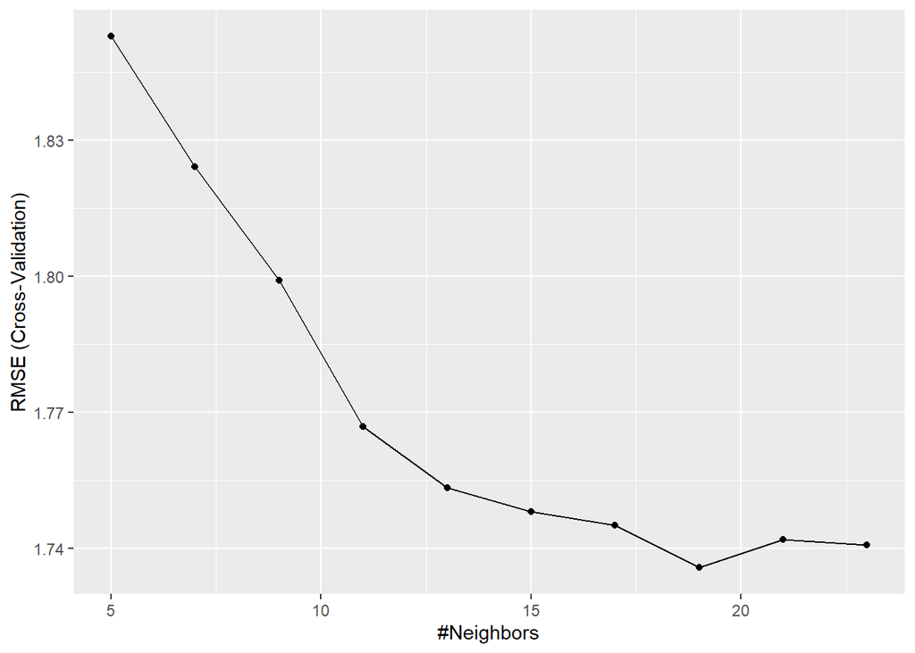

```r
ggplot(train.knn.prediction)
```

```r
test.knn.prediction  <- predict(train.knn.prediction, newdata=test.knn)
error.knn <- test.knn$Rating-test.knn.prediction
print(paste('Error de predicción: ', mae(train$Rating,test.knn.prediction)))
```

```
## [1] "Error de predicción:  1.47232236842105"
```

##### 2. Random Forest

```r
#2. ML --> Random forest
train.randomf <- train(Rating ~
                        Branch * `Customer type` * Month  +
                        Gender  * Payment * `Product line` +
                        Hour + Day + Week +
                        `Unit price`*Quantity, #Fórmula
                       data=train, method="rf",
                       trControl = trainControl("cv", number=5),
                       preProcess = c("center","scale"),
                       tuneLength = 5
)
print(train.randomf)
```

```
## Random Forest
##
## 800 samples
##  11 predictor
##
## Pre-processing: centered (75), scaled (75)
## Resampling: Cross-Validated (5 fold)
## Summary of sample sizes: 641, 639, 640, 641, 639
## Resampling results across tuning parameters:
##
##   mtry  RMSE      Rsquared      MAE
##    2    1.719572  0.0004235755  1.473283
##   20    1.750084  0.0024294145  1.490932
##   38    1.752398  0.0033182249  1.490498
##   56    1.754457  0.0029504528  1.490211
##   75    1.752404  0.0031571456  1.486631
##
## RMSE was used to select the optimal model using the smallest value.
## The final value used for the model was mtry = 2.
```

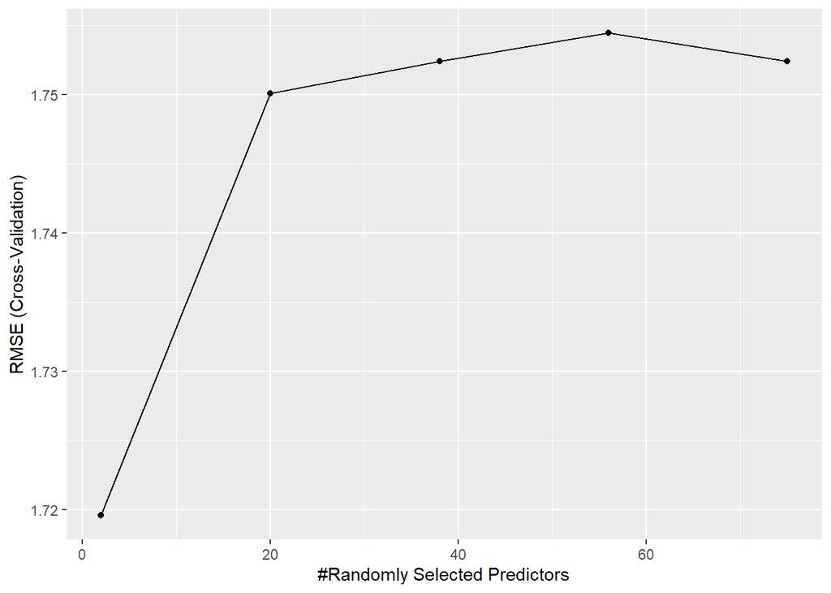

```r
ggplot(train.randomf)
```

```r
test.randomf  <- predict(train.randomf, newdata=test)
error.randomf <- test$Rating-test.randomf
print(paste('Error de predicción: ', mae(train$Rating,test.randomf)))
```

```
## [1] "Error de predicción:  1.46333642848262"
```

#### Pregunta 4

(0.5 puntos) Compare las fortalezas y debilidades de los modelos anteriores, evalúe de acuerdo a algunas de las métricas que vimos en clases y discuta qué modelo recomendaría usar.

Para comparar, se utilizaran las métricas RMSE y MAE. Los resultados se resumen en la siguiente tabla:

```r
#Comparación modelos y recomendación

Metricas=data.frame(Modelo=c("lm1","lm2","lm3","LASSO","Ridge","Stepwise (backward)", "KNN","Random Forest"), RMSE=NA, MAE=NA)


#RMSE
Metricas[1,2] = rmse(train$Rating,test.lm) #lm1
Metricas[2,2] = rmse(train$Rating,test.lm2) #lm2
Metricas[3,2] = rmse(train$Rating,test.lm3) #lm3
Metricas[4,2] = rmse(train$Rating,test.lasso) #lasso
Metricas[5,2] = rmse(train$Rating,test.rr) #ridge
Metricas[6,2] = rmse(train$Rating,test.swb) #swb
Metricas[7,2] = rmse(train.knn$Rating,test.knn.prediction)#knn
Metricas[8,2] = rmse(train$Rating,test.randomf) #rf


#MAPE
Metricas[1,3] = mae(train$Rating,test.lm) #lm1
Metricas[2,3] = mae(train$Rating,test.lm2) #lm2
Metricas[3,3] = mae(train$Rating,test.lm3) #lm3
Metricas[4,3] = mae(train$Rating,test.lasso) #lasso
Metricas[5,3] = mae(train$Rating,test.rr) #ridge
Metricas[6,2] = mae(train$Rating,test.swb) #swb
Metricas[7,2] = mae(train.knn$Rating,test.knn.prediction)#knn
Metricas[8,2] = mae(train$Rating,test.randomf) #rf


kable(Metricas)
```

| Modelo | RMSE | MAE |
| --- | --- | --- |
| lm1 | 1.738273 | 1.472270 |
| lm2 | 1.747472 | 1.480081 |
| lm3 | 1.783657 | 1.495120 |
| LASSO | 1.712271 | 1.468375 |
| Ridge | 1.728981 | 1.464783 |
| Stepwise (backward) | 1.462653 | NA |
| KNN | 1.472322 | NA |
| Random Forest | 1.463336 | NA |

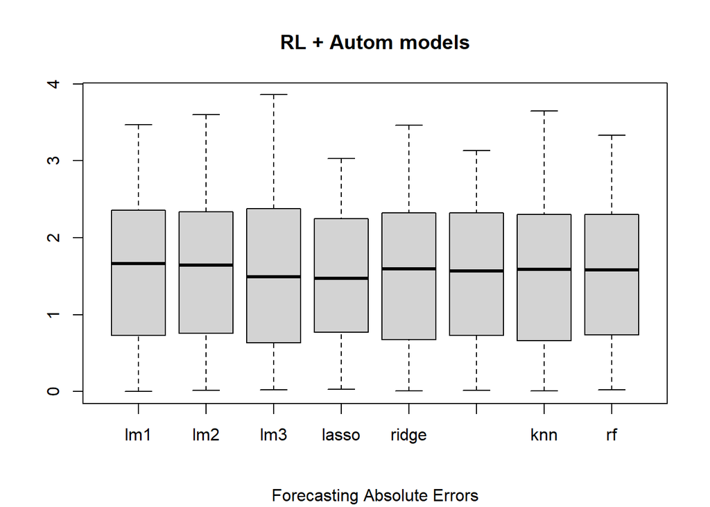

```r
# Dataframe para Boxplots

rating.test <- data.frame(lm1=test.lm, lm2=test.lm2, lm3=test.lm3, lasso=test.lasso, ridge=test.rr, step.back=test.swb, knn=test.knn.prediction, rf=test.randomf, rating=test$Rating)
error.test <- data.frame(lm1=error.lm, lm2=error.lm2, lm3=error.lm3, lasso=error.lasso, ridge=error.rr, step.back=error.swb, knn=error.knn, rf=error.randomf)

boxplot(abs(subset(error.test))); title(main="RL + Autom models", sub="Forecasting Absolute Errors")
```

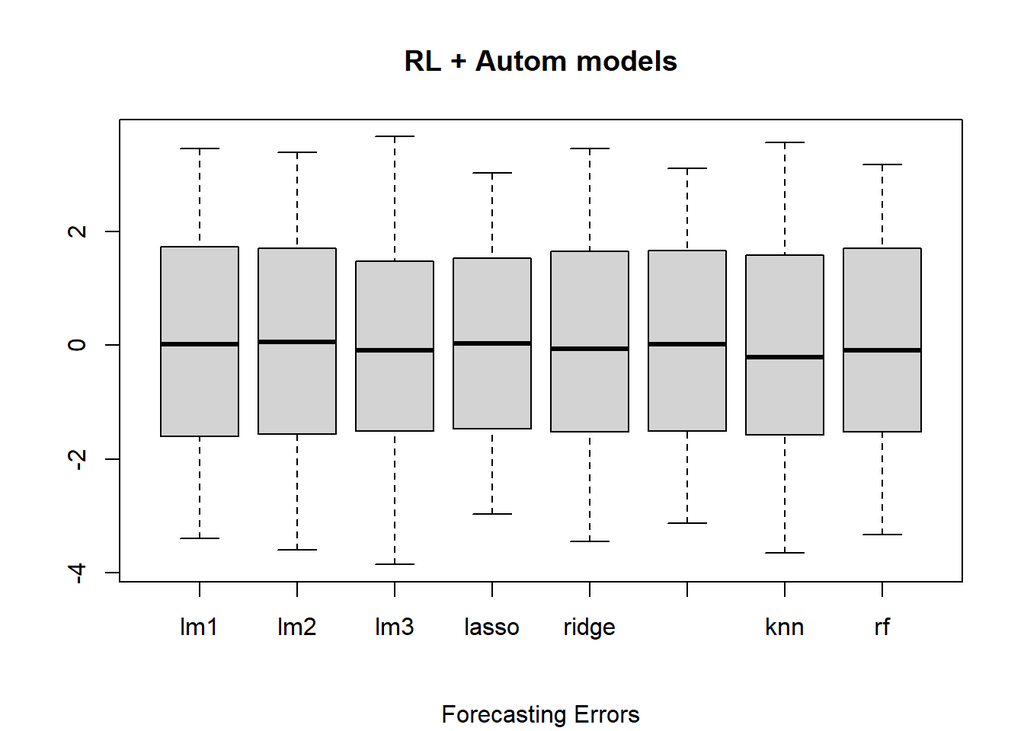

```r
boxplot(subset(error.test)); title(main="RL + Autom models", sub="Forecasting Errors")
```

En cuanto a las fortalezas y debilidades de cada modelo, se tiene que para los de regresión lineal, si bien son los únicos que permiten obtener inferencia estadística, hay que probar varios modelos hasta encontrar uno óptimo, lo cual en este caso no resultaría eficiente pues se vio que lo que explica el modelos son interacciones entre variables, por lo que habría que indagar e invertir bastante tiempo.

#### Pregunta 5

(2.0 puntos) En esta parte, se compararán los grados de satisfacción entre las distintas salas de la cadena de supermercados. Para lo siguiente usted deberá clasificar cada evaluación de la calidad de servicios de acuerdo a si el cliente está o no satisfecho. Para eso puede considerar que un cliente está satisfecho si tiene un Rating mayor o igual a los 7 puntos. Con esto:

**a)**Estimar un modelo de decisión homogéneo para cada sucursal y compare sus resultados entre sucursales. Discuta brevemente sus resultados.

Esta sección se encuentra en el HTML a partir del desrrollo en Python/Jupyter Notebook, por lo que se debe seguir el desarrollo desde allá.

**b)**Estimar un modelo de decisión heterogéneo para cada sucursal y compare sus resultados entre sucursales. Discuta brevemente sus resultados.

Esta sección se encuentra en el HTML a partir del desrrollo en Python/Jupyter Notebook, por lo que se debe seguir el desarrollo desde allá.

## Resumen y Conclusiones

Documenta acá el resumen y las conclusiones principales (esto te servirá para la presentación del jueves 6)

#### Pregunta 6

Finalmente, dado el estudio de modelos desarrollado, se puede concluir, primero, que las variables por sí solas pueden no explicar fenómenos complejos como la decisión de qué nivel de satisfacción se tiene con una atención, pues distintos factores pueden afectar en conjunto. Esto se vio en el EDA inicial y también en las primeras regresiones lineales donde se evluaba cómo una variable independiente podía explicar el Rating, sin embargo, se vio poca significancia y correlación.

En segundo lugar, se vio que los métodos de selección automática tuvieron un rendimiento mejor, lo cual puede deberser a fenómenos que no se pueden ver a simple vista, y que guardan relación con cada posible varibale e interacción.

Por otro lado, para un caso de estudio futuro, sería mejor comprender más a fondo cada uno de los modelos con los que se trabajó para de esta manera, discernir en qué situación ocupar cada uno y cómo tratar los datos tal que se adapte mejor al modelos escogido y obtener mejores resultados.

También se puede concluir que si bien nada predice con un 100% de precisión, una mejora de, por ejemplo, un 1%, puede significar un beneficio para la cadena de supermercados. Esto es, dentro de todos los modelos estudiados, elegir aquel que tuvo mejor rendimiento y que pueda mejorar los resultados de la marca.

Por último, en cuanto a los modelos de decisión (homogeneo y heterogeneo), se observa que las distribuciones sobre los $\theta$ correspondientes a cada Branch dependen bastante poco de la segmentación, al tener parámetros $\alpha$ y $\beta$ muy altos. En general se ve que hay poca certeza a la hora de ver si un cliente está satisfecho, donde la probabilidad en los modelos estudiados siempre se estima cercana a 0.5. Esto daría a entender que es muy difícil hacer inferencias sobre el comportamiento de los distintos clientes, pero si se pueden hacer inferencias del comportamiento agregado de los clientes y segmentos, donde se espera que la fracción de clientes satisfechos esté cercano al 50%.

## Anexos

Documenta acá cualquier otro adicional que consideres útil tener de referencia.

#### Pregunta 2

```r
#48. Boxplot Branch v/s Rating r/ Week
ggplot(df) +
  aes(x=Month, y=Rating, col=Branch:`Customer type`) +
  geom_boxplot(alpha=0.4, fill='white') #cambiamos el tipo de gráfico
```

[output not shown]

#### Pregunta 2

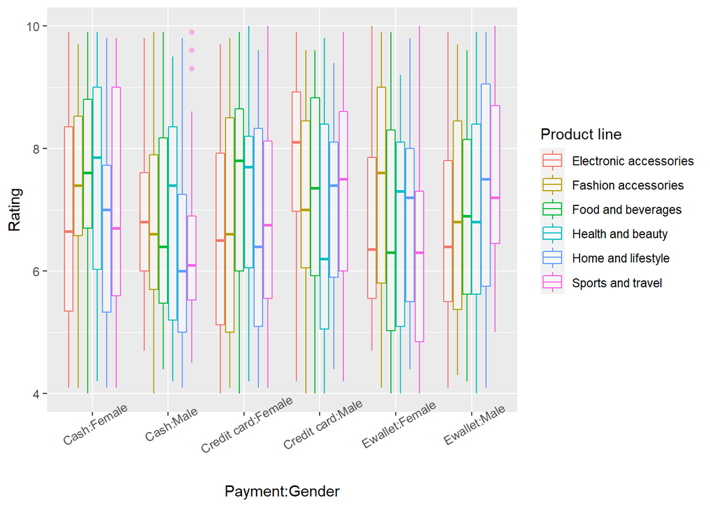

```r
#43. Boxplot Gender:Payment v/s Rating r/ `Product line`
ggplot(df) +
  aes(x=Payment:Gender, y=Rating, col=`Product line`) +
  geom_boxplot(alpha=0.4, fill='white') + #cambiamos el tipo de gráfico
  theme(axis.text.x = element_text(angle = 30))
```